# Analyzing Medical Readmissions with PCA

# Introduction:

### The goal of this project is to determine if it is possible to identify the factors most responsible for patients being readmitted to the hospital. This will be done by using principal component analysis on a medical dataset. To achive this it is vital to understand what PCA is. According to (Vidhya, 2020), "In simple words, PCA is a method of obtaining important variables (in form of components) from a large set of variables available in a data set. It extracts low dimensional set of features by taking a projection of irrelevant dimensions from a high dimensional data set with a motive to capture as much information as possible. With fewer variables obtained while minimising the loss of information, visualization also becomes much more meaningful."

### According to (O’Rourke, 2020) One of the main assumptions of PCA is Linearity. "The relationship between all observed variables should be linear."

# Research Question:

### Can PCA be used to identify the factors most responsible for hospital readmission?

## Step One: Install the necesarry packages

```r
library(ggplot2)
library(tidyverse)
```

```r
install.packages("ggfortify")
```

```r
library(ggfortify)
```

## Step Two: Import the data

```r
data1 <- read_csv("C:\\Users\\ContactTracer\\Desktop\\D212 Data Mining II Task 2\\medical_clean.csv")
```

### Many of the factors included in the dataset will either have no effect on hospital readmission, or will tell nothing of interest about the patients. All unneeded factors will be removed, and then the data will be scaled. The reason for scaling the data is that accoriding to (Vadapalli, 2020) "All variables should be accessed on the same ratio level of measurement." The reason for this is if the scale for one variable was greater then the other variables, that variable would have an undue affect on the PCAs.

```r
data2 <- data1[ -c(1:14, 18:19, 23, 25:39, 43:50) ]
```

```r
data2$ReAdmis <- as.numeric(as.factor(data2$ReAdmis))
```

```r
addmission_data <- data2$ReAdmis
```

```r
data3 <- data2[-c(4)]
```

```r
data_scaled <-scale(data3)
```

```r
write.csv(data_scaled,"C:\\Users\\ContactTracer\\Desktop\\data_scaled.csv", row.names = FALSE)
```

### Now that the data is scaled a covariance matrix can be created

```r
S <- cov(data_scaled)
```

```r
S
```

A matrix: 9 × 9 of type dbl

|  | Children | Age | Income | VitD_levels | Doc_visits | vitD_supp | Initial_days | TotalCharge | Additional_charges |
| --- | --- | --- | --- | --- | --- | --- | --- | --- | --- |
| Children | 1.000000000 | 0.009835607 | 0.007176498 | 0.009487013 | -0.002292199 | -0.004319286 | 0.022466620 | 0.024100265 | 0.013548457 |
| Age | 0.009835607 | 1.000000000 | -0.012228139 | 0.010315387 | 0.006897840 | 0.010014004 | 0.016264290 | 0.016875738 | 0.716853618 |
| Income | 0.007176498 | -0.012228139 | 1.000000000 | -0.013115002 | 0.013463739 | 0.001253438 | -0.012464817 | -0.014345109 | -0.009824976 |
| VitD_levels | 0.009487013 | 0.010315387 | -0.013115002 | 1.000000000 | 0.010210475 | -0.007203220 | -0.003641791 | -0.001403277 | 0.008289993 |
| Doc_visits | -0.002292199 | 0.006897840 | 0.013463739 | 0.010210475 | 1.000000000 | 0.005680941 | -0.006754303 | -0.005043103 | 0.008071608 |
| vitD_supp | -0.004319286 | 0.010014004 | 0.001253438 | -0.007203220 | 0.005680941 | 1.000000000 | 0.015974224 | 0.016924046 | 0.010327340 |
| Initial_days | 0.022466620 | 0.016264290 | -0.012464817 | -0.003641791 | -0.006754303 | 0.015974224 | 1.000000000 | 0.987640266 | 0.004408883 |
| TotalCharge | 0.024100265 | 0.016875738 | -0.014345109 | -0.001403277 | -0.005043103 | 0.016924046 | 0.987640266 | 1.000000000 | 0.029255824 |
| Additional_charges | 0.013548457 | 0.716853618 | -0.009824976 | 0.008289993 | 0.008071608 | 0.010327340 | 0.004408883 | 0.029255824 | 1.000000000 |

```r
sum(diag(S))
```

9

```r
s.eigen <- eigen(S)
```

```r
s.eigen
```

```
eigen() decomposition
$values
[1] 1.99400120 1.71397311 1.01722679 1.01334167 1.00416540 0.99185499 0.97004965
[8] 0.28366996 0.01171723

$vectors
              [,1]        [,2]         [,3]          [,4]         [,5]
 [1,] -0.034637405 -0.01714061  0.170642795 -0.4872777216 -0.541146755
 [2,] -0.087304472 -0.70097831 -0.007768503  0.0146013398 -0.011350334
 [3,]  0.020640127  0.01820389 -0.610809775 -0.3717083867 -0.388134005
 [4,]  0.001570476 -0.01954319  0.539897154 -0.4996783050  0.376656471
 [5,]  0.007234201 -0.01617596 -0.330906145 -0.5913827095  0.483676654
 [6,] -0.024779756 -0.01570502 -0.443355512  0.1569494183  0.424598769
 [7,] -0.700272823  0.09361444 -0.005980279 -0.0005454392  0.003972517
 [8,] -0.701449826  0.08303869 -0.004618832 -0.0023307447  0.005513263
 [9,] -0.087575357 -0.70103844 -0.011094321  0.0113723732 -0.015487393
             [,6]         [,7]          [,8]          [,9]
 [1,]  0.56131217  0.352167530  0.0037294642 -0.0009302585
 [2,] -0.02064614 -0.010685067  0.7066633769  0.0262943903
 [3,] -0.15886455 -0.558654086  0.0022016225  0.0013088884
 [4,]  0.11082004 -0.551625787 -0.0019284637 -0.0015317998
 [5,] -0.25488816  0.491467008  0.0012237570 -0.0011057201
 [6,]  0.76161154 -0.132685333  0.0003295861 -0.0005752266
 [7,] -0.02906538 -0.011945265  0.0316056194 -0.7062691177
 [8,] -0.02776358 -0.011013256 -0.0314695299  0.7064935359
 [9,] -0.01864509 -0.008322533 -0.7061257282 -0.0367823818
```

```r
for (s in s.eigen$values) {
  print(s / sum(s.eigen$values))
}
```

```
[1] 0.2215557
[1] 0.1904415
[1] 0.1130252
[1] 0.1125935
[1] 0.1115739
[1] 0.1102061
[1] 0.1077833
[1] 0.03151888
[1] 0.001301915
```

### From looking at the values of the normalized eginvalues it is clear that only the first 7 PCA's contribute in a meaningful way.

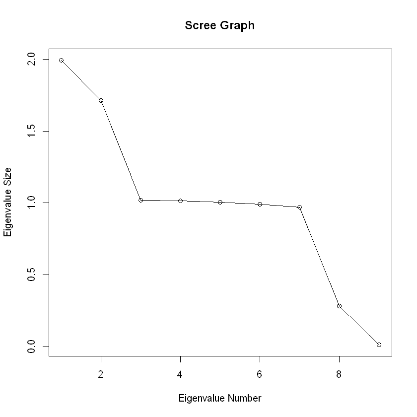

```r
plot(s.eigen$values, xlab = 'Eigenvalue Number', ylab = 'Eigenvalue Size', main = 'Scree Graph')
lines(s.eigen$values)
```

```r
data.pca <- prcomp(data_scaled)
```

```r
data.pca
```

```
Standard deviations (1, .., p=9):
[1] 1.4120911 1.3091880 1.0085766 1.0066487 1.0020805 0.9959192 0.9849110
[8] 0.5326068 0.1082462

Rotation (n x k) = (9 x 9):
                            PC1         PC2          PC3           PC4
Children            0.034637405 -0.01714061  0.170642795  0.4872777216
Age                 0.087304472 -0.70097831 -0.007768503 -0.0146013398
Income             -0.020640127  0.01820389 -0.610809775  0.3717083867
VitD_levels        -0.001570476 -0.01954319  0.539897154  0.4996783050
Doc_visits         -0.007234201 -0.01617596 -0.330906145  0.5913827095
vitD_supp           0.024779756 -0.01570502 -0.443355512 -0.1569494183
Initial_days        0.700272823  0.09361444 -0.005980279  0.0005454392
TotalCharge         0.701449826  0.08303869 -0.004618832  0.0023307447
Additional_charges  0.087575357 -0.70103844 -0.011094321 -0.0113723732
                            PC5         PC6          PC7           PC8
Children            0.541146755 -0.56131217  0.352167530 -0.0037294642
Age                 0.011350334  0.02064614 -0.010685067 -0.7066633769
Income              0.388134005  0.15886455 -0.558654086 -0.0022016225
VitD_levels        -0.376656471 -0.11082004 -0.551625787  0.0019284637
Doc_visits         -0.483676654  0.25488816  0.491467008 -0.0012237570
vitD_supp          -0.424598769 -0.76161154 -0.132685333 -0.0003295861
Initial_days       -0.003972517  0.02906538 -0.011945265 -0.0316056194
TotalCharge        -0.005513263  0.02776358 -0.011013256  0.0314695299
Additional_charges  0.015487393  0.01864509 -0.008322533  0.7061257282
                             PC9
Children            0.0009302585
Age                -0.0262943903
Income             -0.0013088884
VitD_levels         0.0015317998
Doc_visits          0.0011057201
vitD_supp           0.0005752266
Initial_days        0.7062691177
TotalCharge        -0.7064935359
Additional_charges  0.0367823818
```

```r
summary(data.pca)
```

```
Importance of components:
                          PC1    PC2   PC3    PC4    PC5    PC6    PC7     PC8
Standard deviation     1.4121 1.3092 1.009 1.0066 1.0021 0.9959 0.9849 0.53261
Proportion of Variance 0.2216 0.1904 0.113 0.1126 0.1116 0.1102 0.1078 0.03152
Cumulative Proportion  0.2216 0.4120 0.525 0.6376 0.7492 0.8594 0.9672 0.99870
                          PC9
Standard deviation     0.1082
Proportion of Variance 0.0013
Cumulative Proportion  1.0000
```

### The first seven components accout for 97% of the total variation.

```r
pca.plot <- autoplot(data.pca, data = data_scaled)
```

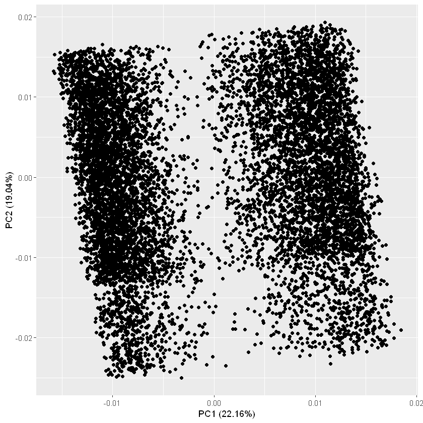

```r
pca.plot
```